# Tugas-pertemuan-4

### Plot ACF

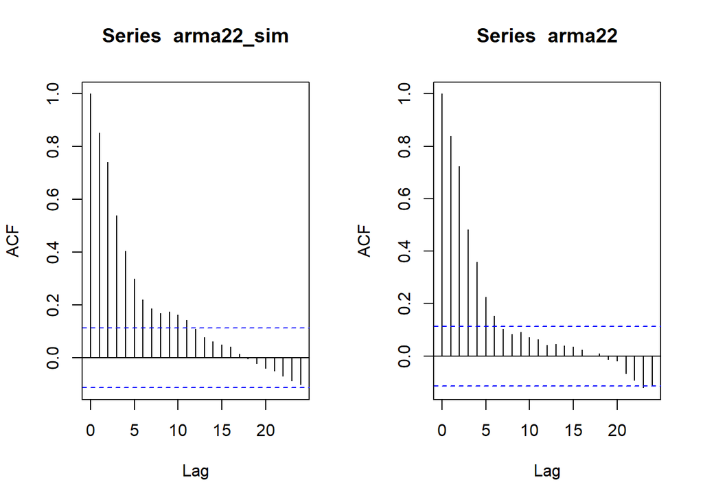

```r
par(mfrow = c(1, 2))
acf(arma22_sim)
acf(arma22)
```

```r
par(mfrow = c(1, 1))
```

Berdasarkan plot ACF tersebut, terlihat bahwa model ARMA(2,2) hasil simulasi memiliki plot ACF yang *tails off*, sesuai dengan teori yang ada

### Plot PACF

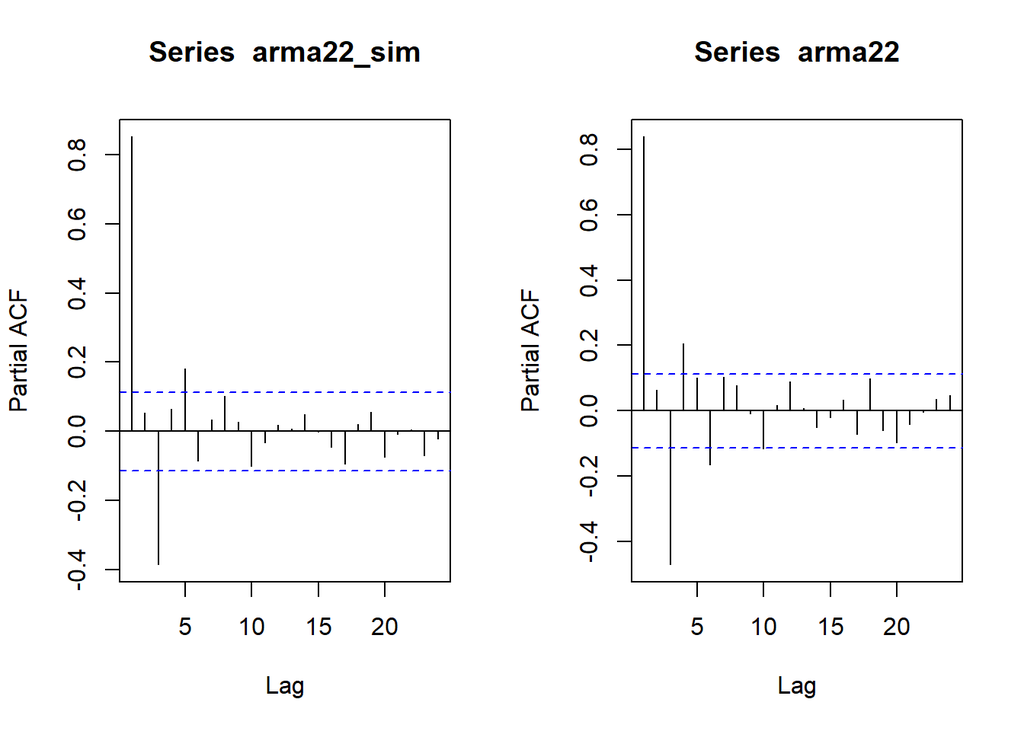

```r
par(mfrow = c(1, 2))
pacf(arma22_sim)
pacf(arma22)
```

```r
par(mfrow = c(1, 1))
```

Berdasarkan plot PACF tersebut, terlihat bahwa model ARMA(2,2) hasil simulasi memiliki plot PACF yang *tails off*, sesuai dengan teori

### Plot EACF

```r
TSA::eacf(arma22_sim)
```

```
## AR/MA
##   0 1 2 3 4 5 6 7 8 9 10 11 12 13
## 0 x x x x x x x x x x x  o  o  o
## 1 o x o o o x o o o o o  o  o  o
## 2 x x o o o o o o o o o  o  o  o
## 3 x x x o o o o o o o o  o  o  o
## 4 x x o o o x o o o o o  o  o  o
## 5 x o x o x o o o o o o  o  o  o
## 6 x o x o x o x o o o o  o  o  o
## 7 x x o o x o x o o o o  o  o  o
```

```r
TSA::eacf(arma22)
```

```
## AR/MA
##   0 1 2 3 4 5 6 7 8 9 10 11 12 13
## 0 x x x x x x o o o o o  o  o  o
## 1 o x x x o o o o o o o  o  o  o
## 2 x x x o o o o o o o o  o  o  o
## 3 x x x o o o o o x o o  o  o  o
## 4 x x o x o o o o o o o  o  o  o
## 5 x x x o o o o o o o o  o  o  o
## 6 x x x o x x x o o o o  o  o  o
## 7 x x x o o o o o o o o  o  o  o
```

### Scatterplot Antar Lag

#### Korelasi antara $Y_t$ dengan $Y_{t-1}$

```r
# Yt (mulai dari data ke-2 sampai ke-300)
yt_arma <- arma22[-1]
yt_arma
```

```
##   [1]  0.511769065 -0.761334920  1.391847450  0.003049309  1.497697350
##   [6]  1.501496287  0.502532051  0.191156217 -0.497740760 -2.518608949
##  [11] -1.366330828 -0.061406363  2.944558720  2.607671974  4.500792022
##  [16]  2.000022066  2.812626679  0.548801559  0.368701135 -1.370428411
##  [21] -1.748867884 -2.176400111 -3.913293336 -2.908241783 -3.041214789
##  [26] -2.351378782 -3.261123506 -4.395651247 -3.797292529 -3.103818856
##  [31] -2.863826747 -1.945252360 -0.512492232  0.053008374 -1.565028830
##  [36] -2.214548269 -2.893236873 -1.948268187 -0.733070229 -1.792205572
##  [41] -2.641010758 -1.743711991 -0.721025372  0.812439037  1.333794840
##  [46]  1.346018270  2.437781448  2.094160611  2.730444854  2.005531438
##  [51]  1.603578207  0.904201795  2.658554214  2.694005863  2.642245241
##  [56]  0.136065284  2.086666966  3.223660549  4.864439952  5.531611683
##  [61]  4.450819152  4.590917509  2.572396480  3.060837246  1.955940225
##  [66]  4.176796484  3.723044581  4.418725020  4.202750493  4.700576927
##  [71]  3.750685922  3.015587441  1.746443610  0.403034303 -0.284698326
```

[output cut: 45 more lines]

```r
# Yt-1 (mulai dari data ke-1 sampai ke-299)
yt_1_arma <- arma22[-300]
yt_1_arma
```

```
##   [1] -1.126305873  0.511769065 -0.761334920  1.391847450  0.003049309
##   [6]  1.497697350  1.501496287  0.502532051  0.191156217 -0.497740760
##  [11] -2.518608949 -1.366330828 -0.061406363  2.944558720  2.607671974
##  [16]  4.500792022  2.000022066  2.812626679  0.548801559  0.368701135
##  [21] -1.370428411 -1.748867884 -2.176400111 -3.913293336 -2.908241783
##  [26] -3.041214789 -2.351378782 -3.261123506 -4.395651247 -3.797292529
##  [31] -3.103818856 -2.863826747 -1.945252360 -0.512492232  0.053008374
##  [36] -1.565028830 -2.214548269 -2.893236873 -1.948268187 -0.733070229
##  [41] -1.792205572 -2.641010758 -1.743711991 -0.721025372  0.812439037
##  [46]  1.333794840  1.346018270  2.437781448  2.094160611  2.730444854
##  [51]  2.005531438  1.603578207  0.904201795  2.658554214  2.694005863
##  [56]  2.642245241  0.136065284  2.086666966  3.223660549  4.864439952
##  [61]  5.531611683  4.450819152  4.590917509  2.572396480  3.060837246
##  [66]  1.955940225  4.176796484  3.723044581  4.418725020  4.202750493
##  [71]  4.700576927  3.750685922  3.015587441  1.746443610  0.403034303
```

[output cut: 45 more lines]

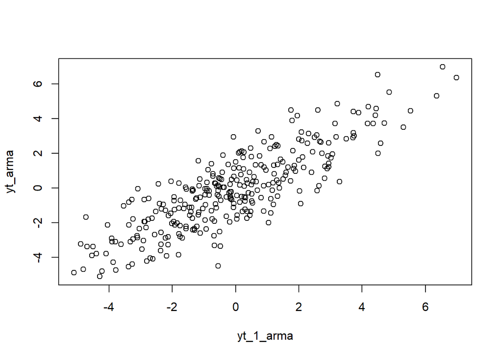

```r
plot(y=yt_arma,x=yt_1_arma)
```

Berdasarkan scatterplot tersebut, terlihat bahwa terdapat hubungan positif antara $Y_t$ dengan $Y_{t-1}$. Hal ini sesuai dengan teori yang ada

```r
cor(yt_arma,yt_1_arma)
```

```
## [1] 0.8393883
```

Korelasi antara $Y_t$ dengan $Y_{t-1}$ dari hasil simulasi mendekati perhitungan teoritis.

#### Korelasi antara $Y_t$ dengan $Y_{t-2}$

```r
# Yt (mulai dari data ke-3 sampai ke-300)
yt_arma2 <- arma22[-c(1,2)]
yt_arma2
```

```
##   [1] -0.761334920  1.391847450  0.003049309  1.497697350  1.501496287
##   [6]  0.502532051  0.191156217 -0.497740760 -2.518608949 -1.366330828
##  [11] -0.061406363  2.944558720  2.607671974  4.500792022  2.000022066
##  [16]  2.812626679  0.548801559  0.368701135 -1.370428411 -1.748867884
##  [21] -2.176400111 -3.913293336 -2.908241783 -3.041214789 -2.351378782
##  [26] -3.261123506 -4.395651247 -3.797292529 -3.103818856 -2.863826747
##  [31] -1.945252360 -0.512492232  0.053008374 -1.565028830 -2.214548269
##  [36] -2.893236873 -1.948268187 -0.733070229 -1.792205572 -2.641010758
##  [41] -1.743711991 -0.721025372  0.812439037  1.333794840  1.346018270
##  [46]  2.437781448  2.094160611  2.730444854  2.005531438  1.603578207
##  [51]  0.904201795  2.658554214  2.694005863  2.642245241  0.136065284
##  [56]  2.086666966  3.223660549  4.864439952  5.531611683  4.450819152
##  [61]  4.590917509  2.572396480  3.060837246  1.955940225  4.176796484
##  [66]  3.723044581  4.418725020  4.202750493  4.700576927  3.750685922
##  [71]  3.015587441  1.746443610  0.403034303 -0.284698326 -1.637990423
```

[output cut: 45 more lines]

```r
# Yt-2 (mulai dari data ke-1 sampai ke-298)
yt_2_arma <- arma22[-c(299,300)]
yt_2_arma
```

```
##   [1] -1.126305873  0.511769065 -0.761334920  1.391847450  0.003049309
##   [6]  1.497697350  1.501496287  0.502532051  0.191156217 -0.497740760
##  [11] -2.518608949 -1.366330828 -0.061406363  2.944558720  2.607671974
##  [16]  4.500792022  2.000022066  2.812626679  0.548801559  0.368701135
##  [21] -1.370428411 -1.748867884 -2.176400111 -3.913293336 -2.908241783
##  [26] -3.041214789 -2.351378782 -3.261123506 -4.395651247 -3.797292529
##  [31] -3.103818856 -2.863826747 -1.945252360 -0.512492232  0.053008374
##  [36] -1.565028830 -2.214548269 -2.893236873 -1.948268187 -0.733070229
##  [41] -1.792205572 -2.641010758 -1.743711991 -0.721025372  0.812439037
##  [46]  1.333794840  1.346018270  2.437781448  2.094160611  2.730444854
##  [51]  2.005531438  1.603578207  0.904201795  2.658554214  2.694005863
##  [56]  2.642245241  0.136065284  2.086666966  3.223660549  4.864439952
##  [61]  5.531611683  4.450819152  4.590917509  2.572396480  3.060837246
##  [66]  1.955940225  4.176796484  3.723044581  4.418725020  4.202750493
##  [71]  4.700576927  3.750685922  3.015587441  1.746443610  0.403034303
```

[output cut: 45 more lines]

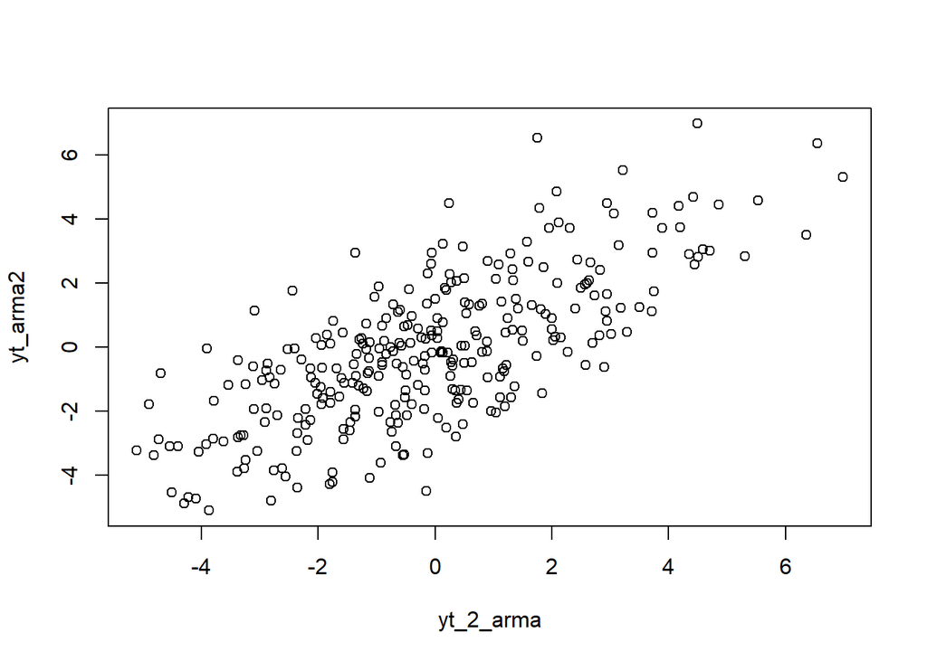

```r
plot(y=yt_arma2,x=yt_2_arma)
```

```r
cor(yt_arma2, yt_2_arma)
```

```
## [1] 0.7229666
```

```r
# Yt (mulai dari data ke-4 sampai ke-300)
yt_arma3 <- arma22[-c(1,2,3)]
yt_arma3
```

```
##   [1]  1.391847450  0.003049309  1.497697350  1.501496287  0.502532051
##   [6]  0.191156217 -0.497740760 -2.518608949 -1.366330828 -0.061406363
##  [11]  2.944558720  2.607671974  4.500792022  2.000022066  2.812626679
##  [16]  0.548801559  0.368701135 -1.370428411 -1.748867884 -2.176400111
##  [21] -3.913293336 -2.908241783 -3.041214789 -2.351378782 -3.261123506
##  [26] -4.395651247 -3.797292529 -3.103818856 -2.863826747 -1.945252360
##  [31] -0.512492232  0.053008374 -1.565028830 -2.214548269 -2.893236873
##  [36] -1.948268187 -0.733070229 -1.792205572 -2.641010758 -1.743711991
##  [41] -0.721025372  0.812439037  1.333794840  1.346018270  2.437781448
##  [46]  2.094160611  2.730444854  2.005531438  1.603578207  0.904201795
##  [51]  2.658554214  2.694005863  2.642245241  0.136065284  2.086666966
##  [56]  3.223660549  4.864439952  5.531611683  4.450819152  4.590917509
##  [61]  2.572396480  3.060837246  1.955940225  4.176796484  3.723044581
##  [66]  4.418725020  4.202750493  4.700576927  3.750685922  3.015587441
##  [71]  1.746443610  0.403034303 -0.284698326 -1.637990423 -1.180160721
```

[output cut: 45 more lines]

```r
# Yt-3 (mulai dari data ke-1 sampai ke-297)
yt_3_arma <- arma22[-c(298,299,300)]
yt_3_arma
```

```
##   [1] -1.126305873  0.511769065 -0.761334920  1.391847450  0.003049309
##   [6]  1.497697350  1.501496287  0.502532051  0.191156217 -0.497740760
##  [11] -2.518608949 -1.366330828 -0.061406363  2.944558720  2.607671974
##  [16]  4.500792022  2.000022066  2.812626679  0.548801559  0.368701135
##  [21] -1.370428411 -1.748867884 -2.176400111 -3.913293336 -2.908241783
##  [26] -3.041214789 -2.351378782 -3.261123506 -4.395651247 -3.797292529
##  [31] -3.103818856 -2.863826747 -1.945252360 -0.512492232  0.053008374
##  [36] -1.565028830 -2.214548269 -2.893236873 -1.948268187 -0.733070229
##  [41] -1.792205572 -2.641010758 -1.743711991 -0.721025372  0.812439037
##  [46]  1.333794840  1.346018270  2.437781448  2.094160611  2.730444854
##  [51]  2.005531438  1.603578207  0.904201795  2.658554214  2.694005863
##  [56]  2.642245241  0.136065284  2.086666966  3.223660549  4.864439952
##  [61]  5.531611683  4.450819152  4.590917509  2.572396480  3.060837246
##  [66]  1.955940225  4.176796484  3.723044581  4.418725020  4.202750493
##  [71]  4.700576927  3.750685922  3.015587441  1.746443610  0.403034303
```

[output cut: 45 more lines]

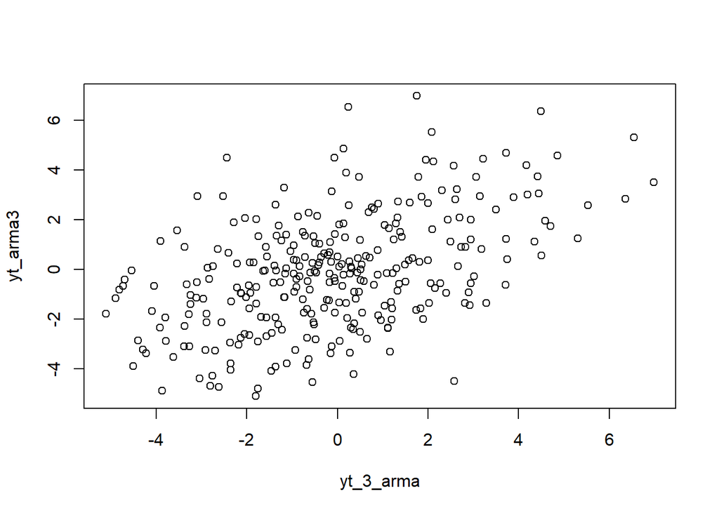

```r
plot(y=yt_arma3,x=yt_3_arma)
```

```r
cor(yt_arma3, yt_3_arma)
```

```
## [1] 0.4823407
```

# Perbandingan korelasi manual dengan korelasi teoritis

```r
# Korelasi teoritis
ARMAacf(ar=c(0.5,0.2), ma=c(0.4,0.6), lag.max=3)
```

```
##         0         1         2         3
## 1.0000000 0.8591993 0.7491908 0.5464353
```

```r
# Korelasi dari simulasi setelah burn-in
cor(yt_arma, yt_1_arma)
```

```
## [1] 0.8393883
```

```r
cor(yt_arma2, yt_2_arma)
```

```
## [1] 0.7229666
```

```r
cor(yt_arma3, yt_3_arma)
```

```
## [1] 0.4823407
```

Berdasarkan hasil tersebut, korelasi yang dilakukan dengan metode manual memiliki nilai yang mendekati korelasi teoritis.